# 1. "ggplot2-R"

Popular data visualization package for R based on grammar of graphics.

### **2.Introduction: **

Data visualization plays a crucial role in understanding, analyzing, and presenting data effectively. ‘’ggplot2’’ is one of the most powerful and widely used visualization libraries in R, designed to create elegant and complex plots with minimal effort. It is a part of the tidyverse ecosystem, developed by Hadley Wickham, and follows the principles of the ‘’Grammar of Graphics’’, which provides a structured approach to building visualizations.

### 3. Installation and setup of 'gglot2-R' on google colab

```r
install.packages("ggplot2")
library(ggplot2)
```

Google Colab primarily supports ‘’Python’’, but you can still use ggplot2 by installing and running ‘’R’’ in Colab.

Step 1: Enable R in Google Colab Open Google Colab (https://colab.research.google.com/). Click on Runtime → Change runtime type. Under Runtime type, select R from the dropdown menu. Click Save. Now, your notebook will support R Step 2: Install and load ggplot2 To install and run ggplot2 on colab, run the following code.

Now, ggplot2 is ready to use.

### 4. Key Features & Explanation:

What is ggplot2?

ggplot2 is an R package that allows users to create stunning and highly customizable graphics using a structured, layered approach. Unlike traditional R plotting functions like plot() or barplot(), ggplot2 provides a consistent and systematic way to build plots by defining components separately and then layering them together.

ggplot2 is preferred over base R graphics because:

Grammar of Graphics Approach → Plots are built step by step using layers (data, aesthetics, geometries).

Highly Customizable → Modify colors, labels, themes, scales, and more. Built-in Datasets → Provides datasets like mpg, diamonds, etc., for quick visualization.

Multiple Plot Types → Supports scatter plots, bar charts, histograms, box plots, etc.

Faceting (Small Multiples) → Easily split data into multiple small plots using facet_wrap().

Theme Control → Allows changing the appearance of plots (theme_minimal(), theme_dark()).

Supports Statistical Transformations → Add trend lines (geom_smooth()), density plots, and more.

Integration with dplyr & tidyverse → Works well with data manipulation libraries.

### Data visualization using the library 'ggplot2-R' from 'R'

### 5. Working examples with explanations and also outputs

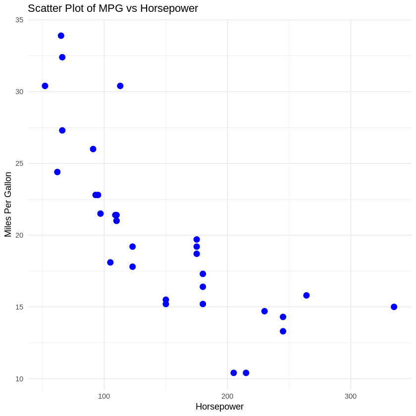

```r
# Scatter plot
# Load ggplot2 library
library(ggplot2)

# Use mtcars dataset
ggplot(data = mtcars, aes(x = hp, y = mpg)) +
  geom_point(color = "blue", size = 3) +  # Scatter plot points
  labs(title = "Scatter Plot of MPG vs Horsepower",
       x = "Horsepower",
       y = "Miles Per Gallon") +
  theme_minimal()  # Clean theme
```

**Explanation for scatter plot**

This R code creates a scatter plot using the ggplot2 library and the built-in 'mtcars' dataset. Here's a step-by-step explanation of the code:

**library(ggplot2)** This line loads the ggplot2 library, which is essential for creating the plot.

**ggplot(data = mtcars, aes(x = hp, y = mpg)) +** This initiates a ggplot object using the 'mtcars' dataset. The aes() function defines the aesthetic mappings:

x = hp: Sets the x-axis to the 'hp' column (horsepower)

y = mpg: Sets the y-axis to the 'mpg' column (miles per gallon)

geom_point(color = "blue", size = 3) + This adds a layer of points to create the scatter plot. The points are customized:

color = "blue": Sets the color of all points to blue

size = 3: Increases the size of the points for better visibility

labs(title = "Scatter Plot of MPG vs Horsepower", x = "Horsepower", y = "Miles Per Gallon") + This function adds labels to the plot:

title: Sets the main title of the plot

x,y : Labels the x and y axis respectively

** theme_minimal()** This applies a minimalist theme to the plot, removing background colors and unnecessary grid lines for a cleaner look.

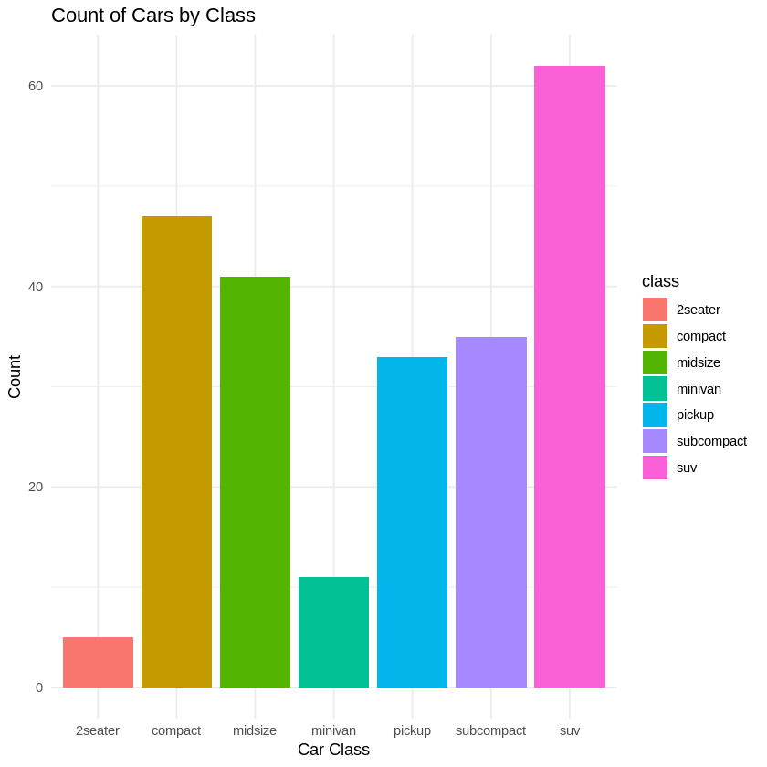

```r
# (Bar chart)
ggplot(mpg, aes(x = class, fill = class)) +
  geom_bar() +
  labs(title = "Count of Cars by Class",
       x = "Car Class",
       y = "Count") +
  theme_minimal()
```

Explanation for Bar chart

ggplot(mpg, aes(x = class, fill = class)) + This initiates a ggplot object using the 'mpg' dataset. The aes() function defines the aesthetic mappings:

x = class: Sets the x-axis to the 'class' column, which represents different car classes

fill = class: Sets the fill color of the bars to be based on the car class, giving each class a unique color

text geom_bar() + This adds a bar geometry to the plot. By default, geom_bar() counts the number of occurrences for each category (in this case, each car class) and creates bars with heights proportional to these counts.

text labs(title = "Count of Cars by Class", x = "Car Class", y = "Count") + This function adds labels to the plot:

title: Sets the main title of the plot

x: Labels the x-axis

y: Labels the y-axis

text theme_minimal() This applies a minimalist theme to the plot, removing background colors and unnecessary grid lines for a cleaner look.

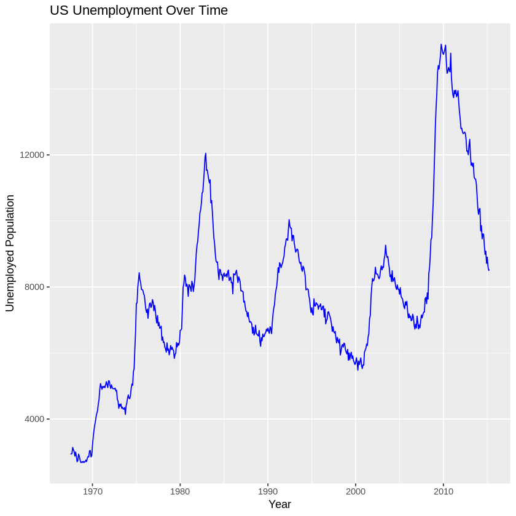

```r
# Line chart
ggplot(economics, aes(x = date, y = unemploy)) +
  geom_line(color = "blue") +
  labs(title = "US Unemployment Over Time",
       x = "Year",
       y = "Unemployed Population")
```

Explanation for Line chart

ggplot(economics, aes(x = date, y = unemploy)) + This initiates a ggplot object using the 'economics' dataset. The aes() function defines the aesthetic mappings:

x = date: Sets the x-axis to the 'date' column, representing time

y = unemploy: Sets the y-axis to the 'unemploy' column, representing the number of unemployed people

text geom_line(color = "blue") + This adds a line geometry to the plot:

geom_line(): Creates a line that connects the data points

color = "blue": Sets the color of the line to blue

text labs(title = "US Unemployment Over Time", x = "Year", y = "Unemployed Population") This function adds labels to the plot:

title: Sets the main title of the plot

x: Labels the x-axis

y: Labels the y-axis

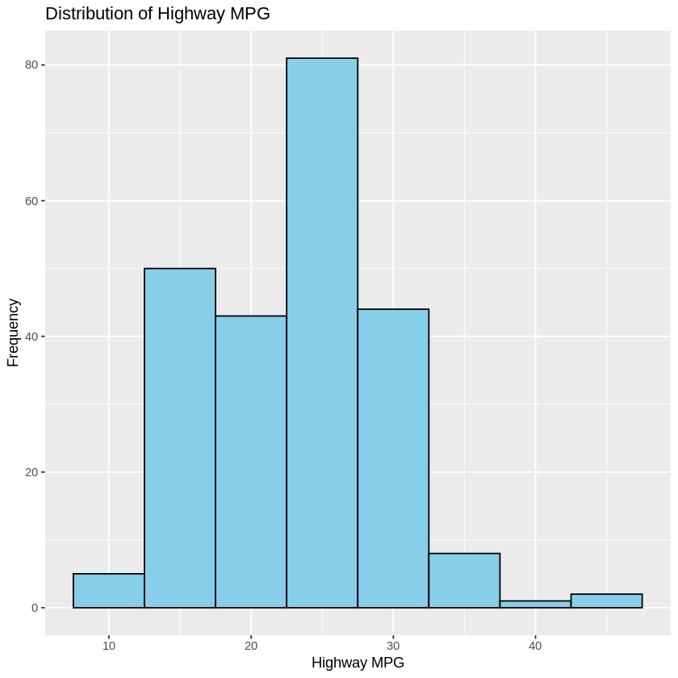

```r
# (Histogram)
ggplot(mpg, aes(x = hwy)) +
  geom_histogram(binwidth = 5, fill = "skyblue", color = "black") +
  labs(title = "Distribution of Highway MPG",
       x = "Highway MPG",
       y = "Frequency")
```

Explnation for Histogram

ggplot(mpg, aes(x = hwy)) + This initiates a ggplot object using the 'mpg' dataset. The aes() function defines the aesthetic mapping:

x = hwy: Sets the x-axis to the 'hwy' column, which represents highway miles per gallon

text geom_histogram(binwidth = 5, fill = "skyblue", color = "black") + This adds a histogram geometry to the plot:

geom_histogram(): Creates a histogram

binwidth = 5: Sets the width of each bin to 5 units of highway MPG

fill = "skyblue": Sets the fill color of the bars to sky blue

color = "black": Sets the outline color of the bars to black

text labs(title = "Distribution of Highway MPG", x = "Highway MPG", y = "Frequency") This function adds labels to the plot:

title: Sets the main title of the plot

x: Labels the x-axis

y: Labels the y-axis

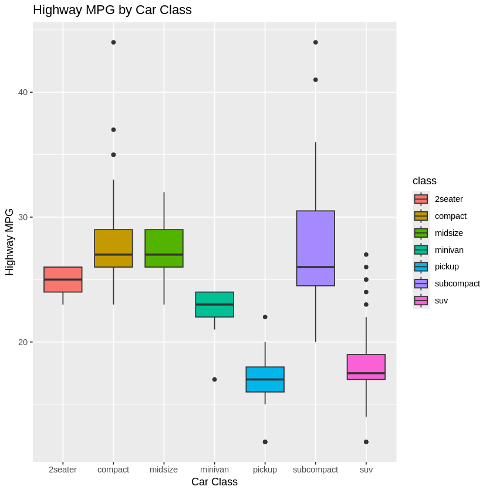

```r
# Box plot
ggplot(mpg, aes(x = class, y = hwy, fill = class)) +
  geom_boxplot() +
  labs(title = "Highway MPG by Car Class",
       x = "Car Class",
       y = "Highway MPG")
```

Explanation for Box plot

geom_boxplot() + This adds a box plot geometry to the plot. Box plots show the distribution of a continuous variable (highway MPG) for each category (car class).

text labs(title = "Highway MPG by Car Class", x = "Car Class", y = "Highway MPG") This function adds labels to the plot:

title: Sets the main title of the plot

x: Labels the x-axis

y: Labels the y-axis

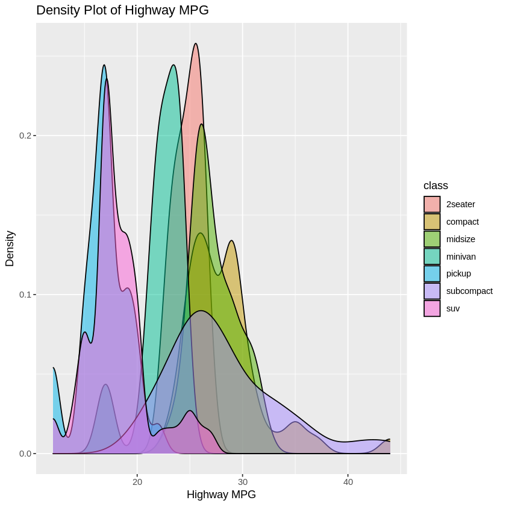

```r
# (Density plot)
ggplot(mpg, aes(x = hwy, fill = class)) +
  geom_density(alpha = 0.5) +
  labs(title = "Density Plot of Highway MPG",
       x = "Highway MPG",
       y = "Density")
```

Explanation for Density plot

ggplot(mpg, aes(x = hwy, fill = class)) + This initiates a ggplot object using the 'mpg' dataset. The aes() function defines the aesthetic mappings:

x = hwy: Sets the x-axis to the 'hwy' column, representing highway miles per gallon

fill = class: Sets the fill color of the density curves to be based on the car class, giving each class a unique color

text geom_density(alpha = 0.5) + This adds a density plot geometry to the plot:

geom_density(): Creates smooth density estimates for each class

alpha = 0.5: Sets the transparency of the fill colors to 50%, allowing overlapping areas to be visible

text labs(title = "Density Plot of Highway MPG", x = "Highway MPG", y = "Density") This function adds labels to the plot:

title: Sets the main title of the plot

x: Labels the x-axis

y: Labels the y-axis

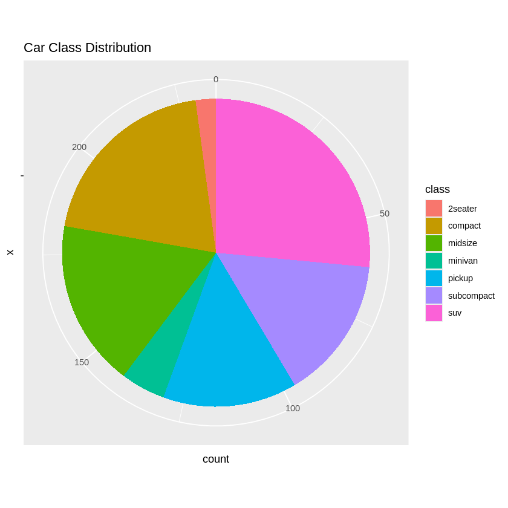

```r
# Pie chart
ggplot(mpg, aes(x = "", fill = class)) +
  geom_bar(width = 1) +
  coord_polar("y") +
  labs(title = "Car Class Distribution")
```

Explanation for Pie chart

ggplot(mpg, aes(x = "", fill = class)) + This initiates a ggplot object using the 'mpg' dataset. The aes() function defines the aesthetic mappings:

x = "": Sets an empty x-axis, which is necessary for creating a pie chart

fill = class: Sets the fill color of the sectors based on the car class

text geom_bar(width = 1) + This adds a bar geometry to the plot:

geom_bar(): Creates bars representing the count of each car class

width = 1: Sets the width of the bars to 1, ensuring they fill the entire plot area

text coord_polar("y") + This transforms the plot coordinates to polar coordinates:

coord_polar("y"): Converts the bar chart into a circular plot, effectively creating a pie chart

text labs(title = "Car Class Distribution") This function adds a title to the plot.

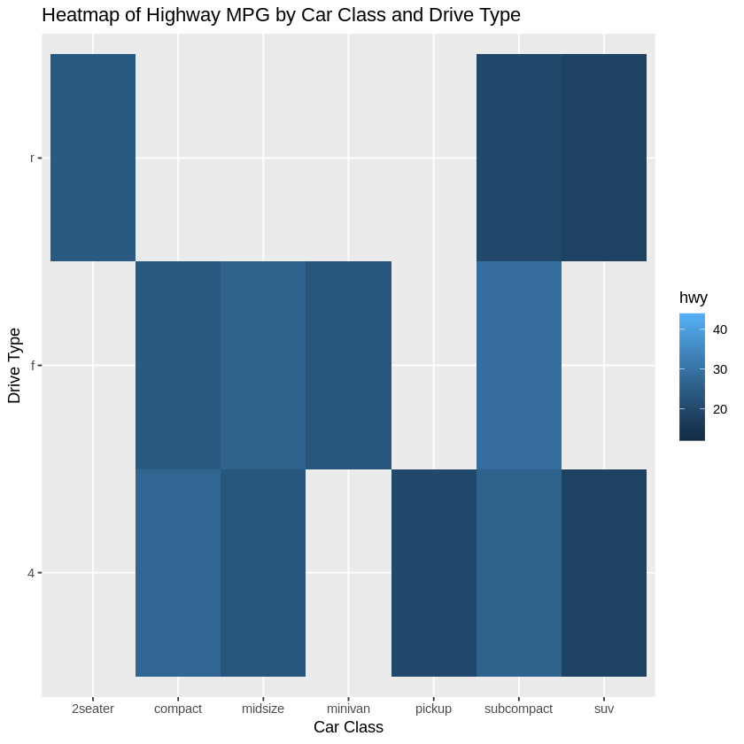

```r
# (Heat map)
ggplot(mpg, aes(x = class, y = drv, fill = hwy)) +
  geom_tile() +
  labs(title = "Heatmap of Highway MPG by Car Class and Drive Type",
       x = "Car Class",
       y = "Drive Type")
```

Explanation for Heat map

ggplot(mpg, aes(x = class, y = drv, fill = hwy)) + This initiates a ggplot object using the 'mpg' dataset. The aes() function defines the aesthetic mappings:

x = class: Sets the x-axis to the 'class' column, representing different car classes

y = drv: Sets the y-axis to the 'drv' column, representing drive types

fill = hwy: Sets the fill color of the tiles based on the 'hwy' column (highway miles per gallon)

text geom_tile() + This adds a tile geometry to the plot. Each tile represents a combination of car class and drive type, with the color intensity indicating the highway MPG.

text labs(title = "Heatmap of Highway MPG by Car Class and Drive Type", x = "Car Class", y = "Drive Type") This function adds labels to the plot:

title: Sets the main title of the plot

x: Labels the x-axis

y: Labels the y-axis

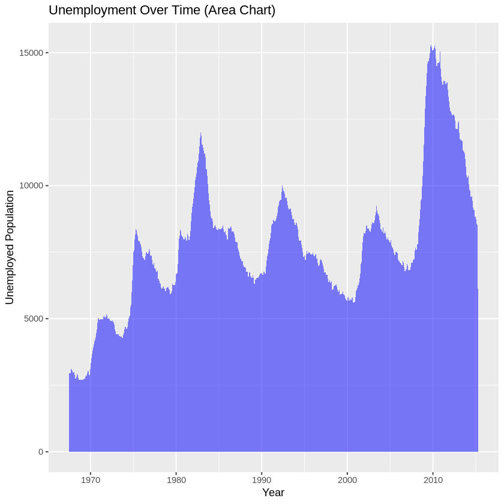

```r
# (Area chart)
ggplot(economics, aes(x = date, y = unemploy)) +
  geom_area(fill = "blue", alpha = 0.5) +
  labs(title = "Unemployment Over Time (Area Chart)",
       x = "Year",
       y = "Unemployed Population")
```

Explanation for area chart

ggplot(economics, aes(x = date, y = unemploy)) + This initiates a ggplot object using the 'economics' dataset. The aes() function defines the aesthetic mappings:

x = date: Sets the x-axis to the 'date' column, representing time

y = unemploy: Sets the y-axis to the 'unemploy' column, representing the number of unemployed people

text geom_area(fill = "blue", alpha = 0.5) + This adds an area geometry to the plot:

geom_area(): Creates an area plot, filling the space between the line and the x-axis

fill = "blue": Sets the fill color of the area to blue

alpha = 0.5: Sets the transparency of the fill to 50%

text labs(title = "Unemployment Over Time (Area Chart)", x = "Year", y = "Unemployed Population") This function adds labels to the plot:

title: Sets the main title of the plot

x: Labels the x-axis

y: Labels the y-axis

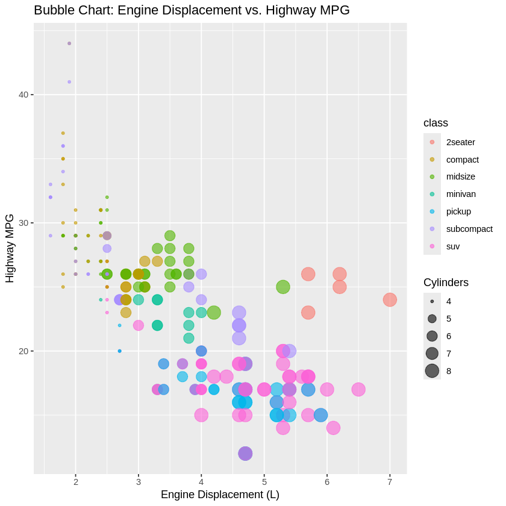

```r
# (Bubble plot)
ggplot(mpg, aes(x = displ, y = hwy, size = cyl, color = class)) +
  geom_point(alpha = 0.6) +
  labs(title = "Bubble Chart: Engine Displacement vs. Highway MPG",
       x = "Engine Displacement (L)",
       y = "Highway MPG",
       size = "Cylinders")
```

Explanation for Bubble plot

ggplot(mpg, aes(x = displ, y = hwy, size = cyl, color = class)) + This initiates a ggplot object using the 'mpg' dataset. The aes() function defines the aesthetic mappings:

x = displ: Sets the x-axis to the 'displ' column (engine displacement in liters)

y = hwy: Sets the y-axis to the 'hwy' column (highway miles per gallon)

size = cyl: Sets the size of the points based on the 'cyl' column (number of cylinders)

color = class: Sets the color of the points based on the 'class' column (car class)

text geom_point(alpha = 0.6) + This adds point geometry to create the bubble plot:

geom_point(): Creates scatter plot points

text labs(title = "Bubble Chart: Engine Displacement vs. Highway MPG", x = "Engine Displacement (L)", y = "Highway MPG", size = "Cylinders") This function adds labels to the plot:

title: Sets the main title of the plot

x: Labels the x-axis

y: Labels the y-axis

size: Labels the legend for the size aesthetic (number of cylinders)

### 6. Screenshots

[figure not shown]

[figure not shown]

### 7.Use cases

practical applications

1.Data Journalism and Public Communication: ggplot2 is used to create clear, engaging visualizations of complex data for news articles, social media, and public health communications. This has been particularly crucial for explaining trends and statistics related to global issues like the COVID-19 pandemic.

2.Business Intelligence and Decision Making: Companies use ggplot2 to visualize key performance indicators, market trends, and customer behavior. These visualizations help in making data-driven decisions and presenting insights to stakeholders.

3.Environmental and Climate Science: Researchers use ggplot2 to visualize climate data, showing trends in temperature, sea levels, and emissions. These visualizations are critical for understanding and communicating the impacts of climate change.

4.Machine Learning Model Evaluation: Data scientists use ggplot2 to create visualizations that help evaluate and explain machine learning models. This includes ROC curves, precision-recall curves, and feature importance plots, which are essential in fields like finance, healthcare, and tech.

5.Social Media and Digital Marketing Analysis: Marketers use ggplot2 to visualize engagement metrics, user behavior, and campaign performance across various social media platforms and digital marketing channels. These insights drive strategy and optimize online presence for businesses and organizations.

### 8. Conclusion:

ggplot2 stands as a powerful and versatile tool for data visualization in R, offering a wide range of plot types and customization options. Through our exploration of various chart types - from scatter plots and bar charts to more complex visualizations like heat maps and bubble plots - we've seen how ggplot2 can effectively communicate diverse data insights.

The package's layered approach to building graphics provides flexibility and control, allowing users to create both simple and sophisticated visualizations. Its consistent syntax across different plot types reduces the learning curve, making it accessible to beginners while offering depth for advanced users.

Compared to Matplotlib, ggplot2 often proves superior for many data visualization tasks. Its declarative syntax and grammar of graphics approach result in more concise, readable code. ggplot2's aesthetic defaults typically produce polished, publication-ready plots with minimal tweaking, saving time and effort. While Matplotlib offers extensive customization, ggplot2's intuitive design philosophy aligns more closely with the principles of effective data visualization, making it easier to create compelling and informative graphics quickly.

As data continues to play a crucial role in decision-making across industries, mastering ggplot2 equips analysts and researchers with the skills to transform raw data into compelling visual narratives, driving insights and informed actions.

### 9. References

To know what is gggplot, grammar of graphics and why is it used: https://ggplot2-book.org/introduction

For learning basic syntax: https://librarycarpentry.github.io/lc-r/instructor/04-data-viz-ggplot.html

For knowing the use cases, features, workflowof ggplot2: https://www.devopsschool.com/blog/what-is-ggplot2-and-use-cases-of-ggplot2/

For learning different types of plots that can be created and functions used: https://towardsdatascience.com/matplotlib-vs-ggplot2-c86dd35a9378/

For finding differences between matplotlib and ggplot2: https://stackshare.io/stackups/ggplot2-vs-matplotlib